# Stacked results for Stage

Bayesian Analyses for mIF data for TIME

Jose Laborde

Monday December 20, 2021

# 1 Objective

To develop Bayesian models and software for the analysis of mIF data and determination of immune subtypes while accounting for the zero-inflated nature of the immune count data. mIF data often contain many samples in which no cells are positive for a given immune marker (i.e., many zero counts). Further, TMAs/tissue sections usually contain multiple cores/regions of interest (ROIs) that are correlated with one another as well as different immune cell types that co-localize. Here, we will develop a Bayesian zero-inflated beta-binomial model and an integrated Bayesian clustering approach to determine immune subtypes that leverage both the abundance and the spatial contexture of immune cells while also incorporating the relationship between markers and multiple measurements from a single tumor sample. We developed a Bayesian analysis of multiplex immunofluorescence data with 8 different models with various levels of zero-inflation or over-dispersion modeled:

- `fit1`: Binomial (B)
- `fit2`: Poisson (P)
- `fit3`: Negative Binomial (NB)
- `fit4`: Zero Inflated Binomial (ZIB)
- `fit5`: Zero Inflated Poisson (ZIP)
- `fit6`: Zero Inflated Negative Binomial (ZINB)
- `fit7`: Beta-Binomial (BB)
- `fit8`: Zero Inflated Beta-Binomial (ZIBB which is still pending for now)

# 2 Data

We will be using the `Peres IF_AACES_NCOCS full data 12092020.rds` data file which I have and pre-processed stored locally. This dataset originally lives in the shared folder `smb://hlm/data/lab/Lab_Fridley/bayesTIME/results/`. Each model above has been ran using [`brms`](https://paul-buerkner.github.io/brms/). Here is a small example of how that (larger) dataset looks like:

```r
dfmif = readRDS("Sample_mIF_data.rds")
head(dfmif,10)
```

|  | suid | stage_group | total_cells | foxp3_opal_540_positive_cells | cd3_opal_650_positive_cells | cd8_opal_570_positive_cells | cd11b_opal_620_positive_cells | cd15_opal_520_positive_cells | cd3plus_foxp3plus_cells | cd3plus_cd8plus_cells | cd11bplus_cd15plus_cells |
| --- | --- | --- | --- | --- | --- | --- | --- | --- | --- | --- | --- |
| 1 | 110188 | Stage 1 or 2 | 2675 | 76 | 134 | 108 | 5 | 1 | 48 | 66 | 0 |
| 2 | 110188 | Stage 1 or 2 | 3098 | 203 | 248 | 99 | 1 | 1 | 193 | 81 | 0 |
| 3 | 110188 | Stage 1 or 2 | 2739 | 14 | 31 | 9 | 0 | 0 | 7 | 5 | 0 |
| 4 | 110190 | Stage 1 or 2 | 2486 | 8 | 51 | 0 | 21 | 1 | 7 | 0 | 1 |
| 5 | 110190 | Stage 1 or 2 | 2506 | 29 | 188 | 10 | 0 | 0 | 26 | 10 | 0 |
| 6 | 110190 | Stage 1 or 2 | 2637 | 22 | 335 | 2 | 1 | 0 | 20 | 2 | 0 |
| 7 | 110206 | Stage 3 | 2123 | 125 | 412 | 143 | 16 | 0 | 121 | 140 | 0 |
| 8 | 110206 | Stage 3 | 2223 | 177 | 606 | 209 | 21 | 2 | 174 | 207 | 2 |
| 9 | 110206 | Stage 3 | 2434 | 145 | 372 | 30 | 4 | 1 | 131 | 30 | 1 |
| 10 | 110212 | Stage 3 | 3187 | 0 | 0 | 2 | 0 | 0 | 0 | 0 | 0 |

The Bayesian models ran above have been stored on the files:

- `BRMS_models_foxp3_opal_540_positive_cells.RData`
- `BRMS_models_cd3_opal_650_positive_cells.RData`
- `BRMS_models_cd8_opal_570_positive_cells.RData`
- `BRMS_models_cd11b_opal_620_positive_cells.RData`
- `BRMS_models_cd15_opal_520_positive_cells.RData`
- `BRMS_models_cd3plus_foxp3plus_cells.RData`
- `BRMS_models_cd3plus_cd8plus_cells.RData`
- `BRMS_models_cd11bplus_cd15plus_cells.RData`

```r
library(brms)
library(bayestestR)
library(bayesplot)
library(dplyr)
library(kableExtra)
library(ggplot2)
library(tidyverse)
library(tidybayes)
```

# 3 Results

## 3.1 `foxp3_opal_540_positive_cells`

The contents of the `BRMS_models_foxp3_opal_540_positive_cells.RData` file are:

```r
load("BRMS_models_foxp3_opal_540_positive_cells.RData")
my_vars = as.data.frame(eapply(.GlobalEnv,typeof))
head(my_vars)
```

|  | dfmif | log_lik_beta_binomial2 | time_fit1 | beta_binomial2 | time_fit2 | time_fit3 | stan_beta_binomial2 | time_fit4 | time_fit5 | time_fit6 | time_fit7 | predict_beta_binomial2 | fit1 | fit2 | fit3 | fit4 | fit5 | fit6 | fit7 | stanvars | fitted_beta_binomial2 |
| --- | --- | --- | --- | --- | --- | --- | --- | --- | --- | --- | --- | --- | --- | --- | --- | --- | --- | --- | --- | --- | --- |
| 1 | list | closure | double | list | double | double | character | double | double | double | double | closure | list | list | list | list | list | list | list | list | closure |

```r
post1 = data.frame(b_stage_groupStage3 = posterior_samples(fit1)$b_stage_groupStage3, model = rep("B", 40000))
post2 = data.frame(b_stage_groupStage3 = posterior_samples(fit2)$b_stage_groupStage3, model = rep("P", 40000))
post3 = data.frame(b_stage_groupStage3 = posterior_samples(fit3)$b_stage_groupStage3, model = rep("NB", 40000))
post4 = data.frame(b_stage_groupStage3 = posterior_samples(fit4)$b_stage_groupStage3, model = rep("ZIB", 40000))
post5 = data.frame(b_stage_groupStage3 = posterior_samples(fit5)$b_stage_groupStage3, model = rep("ZIP", 40000))
post6 = data.frame(b_stage_groupStage3 = posterior_samples(fit6)$b_stage_groupStage3, model = rep("ZINB", 40000))
post7 = data.frame(b_stage_groupStage3 = posterior_samples(fit7)$b_stage_groupStage3, model = rep("BB", 40000))
posts = rbind(post1,post2,post3,post4,post5,post6,post7)
head(posts)
```

|  | b_stage_groupStage3 | model |
| --- | --- | --- |
| 1 | -0.3713051 | B |
| 2 | -0.6348487 | B |
| 3 | -0.6150483 | B |
| 4 | -0.5248865 | B |
| 5 | -0.5841589 | B |
| 6 | -0.7808993 | B |

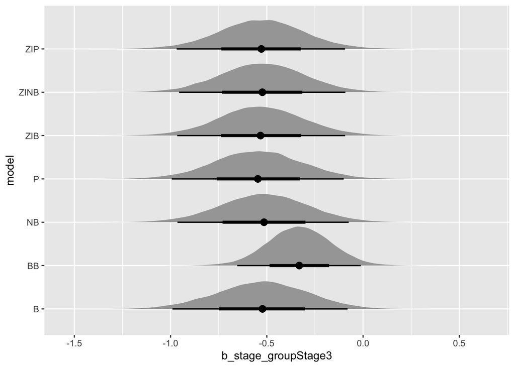

```r
posts %>%
  ggplot(aes(x = b_stage_groupStage3, y = model)) +
  stat_halfeye()
```

## 3.2 `cd3_opal_650_positive_cells`

The contents of the `BRMS_models_cd3_opal_650_positive_cells.RData` file are:

```r
rm(list = ls())
load("BRMS_models_cd3_opal_650_positive_cells.RData")
my_vars = as.data.frame(eapply(.GlobalEnv,typeof))
head(my_vars)
```

|  | fitted_beta_binomial2 | time_fit1 | time_fit2 | predict_beta_binomial2 | log_lik_beta_binomial2 | beta_binomial2 | time_fit3 | time_fit4 | time_fit5 | time_fit6 | time_fit7 | fit1 | stan_beta_binomial2 | fit2 | fit3 | stanvars | fit4 | fit5 | fit6 | fit7 |
| --- | --- | --- | --- | --- | --- | --- | --- | --- | --- | --- | --- | --- | --- | --- | --- | --- | --- | --- | --- | --- |
| 1 | closure | double | double | closure | closure | list | double | double | double | double | double | list | character | list | list | list | list | list | list | list |

```r
post1 = data.frame(b_stage_groupStage3 = posterior_samples(fit1)$b_stage_groupStage3, model = rep("B", 40000))
post2 = data.frame(b_stage_groupStage3 = posterior_samples(fit2)$b_stage_groupStage3, model = rep("P", 40000))
post3 = data.frame(b_stage_groupStage3 = posterior_samples(fit3)$b_stage_groupStage3, model = rep("NB", 40000))
post4 = data.frame(b_stage_groupStage3 = posterior_samples(fit4)$b_stage_groupStage3, model = rep("ZIB", 40000))
post5 = data.frame(b_stage_groupStage3 = posterior_samples(fit5)$b_stage_groupStage3, model = rep("ZIP", 40000))
post6 = data.frame(b_stage_groupStage3 = posterior_samples(fit6)$b_stage_groupStage3, model = rep("ZINB", 40000))
post7 = data.frame(b_stage_groupStage3 = posterior_samples(fit7)$b_stage_groupStage3, model = rep("BB", 40000))
posts = rbind(post1,post2,post3,post4,post5,post6,post7)
head(posts)
```

|  | b_stage_groupStage3 | model |
| --- | --- | --- |
| 1 | -0.4020520 | B |
| 2 | -0.2581357 | B |
| 3 | -0.2855503 | B |
| 4 | -0.2926429 | B |
| 5 | -0.3290705 | B |
| 6 | -0.3617004 | B |

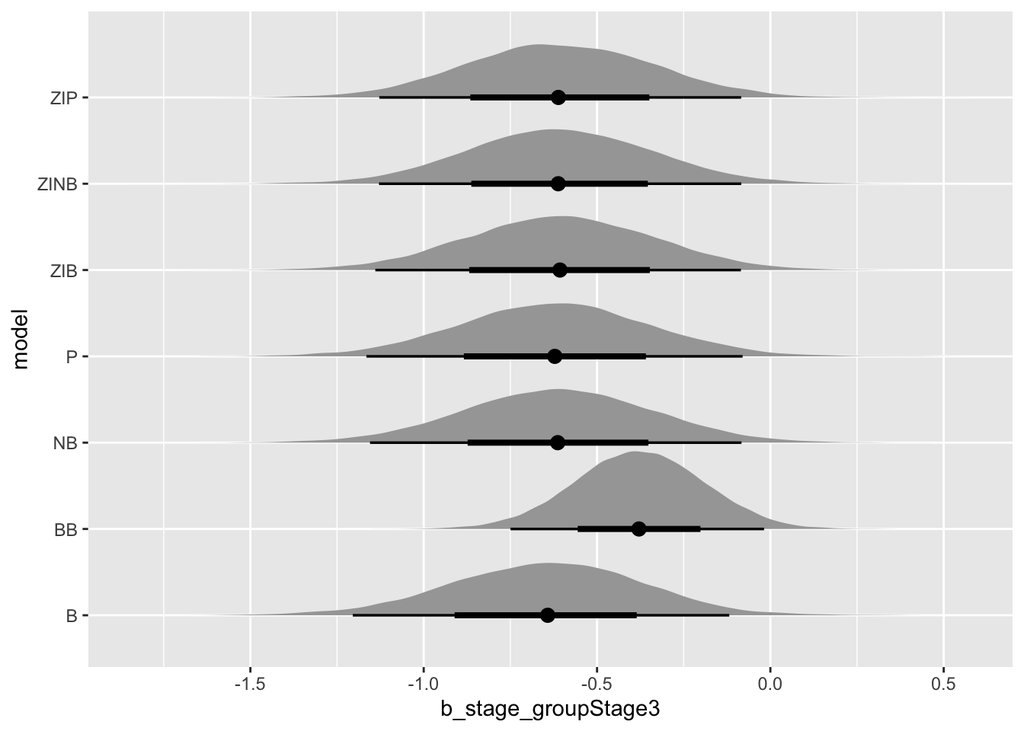

```r
posts %>%
  ggplot(aes(x = b_stage_groupStage3, y = model)) +
  stat_halfeye()
```

## 3.3 `cd8_opal_570_positive_cells`

The contents of the `BRMS_models_cd8_opal_570_positive_cells.RData` file are:

```r
rm(list = ls())
load("BRMS_models_cd8_opal_570_positive_cells.RData")
my_vars = as.data.frame(eapply(.GlobalEnv,typeof))
head(my_vars)
```

|  | stanvars | beta_binomial2 | log_lik_beta_binomial2 | time_fit1 | time_fit2 | predict_beta_binomial2 | time_fit3 | time_fit4 | time_fit5 | fit1 | time_fit6 | fit2 | time_fit7 | fit3 | fit4 | fit5 | stan_beta_binomial2 | fit6 | fit7 | fitted_beta_binomial2 |
| --- | --- | --- | --- | --- | --- | --- | --- | --- | --- | --- | --- | --- | --- | --- | --- | --- | --- | --- | --- | --- |
| 1 | list | list | closure | double | double | closure | double | double | double | list | double | list | double | list | list | list | character | list | list | closure |

```r
post1 = data.frame(b_stage_groupStage3 = posterior_samples(fit1)$b_stage_groupStage3, model = rep("B", 40000))
post2 = data.frame(b_stage_groupStage3 = posterior_samples(fit2)$b_stage_groupStage3, model = rep("P", 40000))
post3 = data.frame(b_stage_groupStage3 = posterior_samples(fit3)$b_stage_groupStage3, model = rep("NB", 40000))
post4 = data.frame(b_stage_groupStage3 = posterior_samples(fit4)$b_stage_groupStage3, model = rep("ZIB", 40000))
post5 = data.frame(b_stage_groupStage3 = posterior_samples(fit5)$b_stage_groupStage3, model = rep("ZIP", 40000))
post6 = data.frame(b_stage_groupStage3 = posterior_samples(fit6)$b_stage_groupStage3, model = rep("ZINB", 40000))
post7 = data.frame(b_stage_groupStage3 = posterior_samples(fit7)$b_stage_groupStage3, model = rep("BB", 40000))
posts = rbind(post1,post2,post3,post4,post5,post6,post7)
head(posts)
```

|  | b_stage_groupStage3 | model |
| --- | --- | --- |
| 1 | -0.06254422 | B |
| 2 | -0.05547212 | B |
| 3 | -0.19583619 | B |
| 4 | -0.29408048 | B |
| 5 | -0.50586571 | B |
| 6 | -0.66451270 | B |

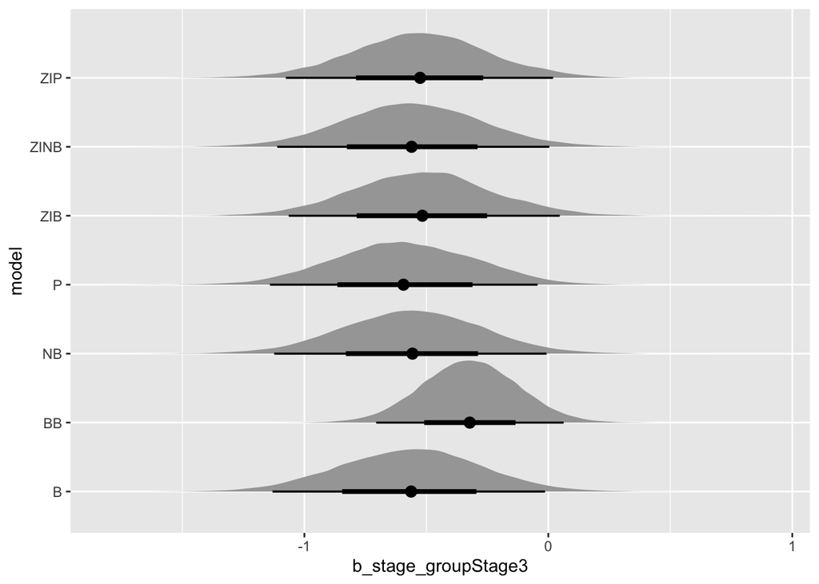

```r
posts %>%
  ggplot(aes(x = b_stage_groupStage3, y = model)) +
  stat_halfeye()
```

## 3.4 `cd11b_opal_620_positive_cells`

The contents of the `BRMS_models_cd11b_opal_620_positive_cells.RData` file are:

```r
rm(list = ls())
load("BRMS_models_cd11b_opal_620_positive_cells.RData")
my_vars = as.data.frame(eapply(.GlobalEnv,typeof))
head(my_vars)
```

|  | stan_beta_binomial2 | predict_beta_binomial2 | fit1 | fit2 | fit3 | fit4 | fit5 | fit6 | fit7 | stanvars | log_lik_beta_binomial2 | time_fit1 | time_fit2 | beta_binomial2 | time_fit3 | time_fit4 | time_fit5 | time_fit6 | time_fit7 | fitted_beta_binomial2 |
| --- | --- | --- | --- | --- | --- | --- | --- | --- | --- | --- | --- | --- | --- | --- | --- | --- | --- | --- | --- | --- |
| 1 | character | closure | list | list | list | list | list | list | list | list | closure | double | double | list | double | double | double | double | double | closure |

```r
post1 = data.frame(b_stage_groupStage3 = posterior_samples(fit1)$b_stage_groupStage3, model = rep("B", 40000))
post2 = data.frame(b_stage_groupStage3 = posterior_samples(fit2)$b_stage_groupStage3, model = rep("P", 40000))
post3 = data.frame(b_stage_groupStage3 = posterior_samples(fit3)$b_stage_groupStage3, model = rep("NB", 40000))
post4 = data.frame(b_stage_groupStage3 = posterior_samples(fit4)$b_stage_groupStage3, model = rep("ZIB", 40000))
post5 = data.frame(b_stage_groupStage3 = posterior_samples(fit5)$b_stage_groupStage3, model = rep("ZIP", 40000))
post6 = data.frame(b_stage_groupStage3 = posterior_samples(fit6)$b_stage_groupStage3, model = rep("ZINB", 40000))
post7 = data.frame(b_stage_groupStage3 = posterior_samples(fit7)$b_stage_groupStage3, model = rep("BB", 40000))
posts = rbind(post1,post2,post3,post4,post5,post6,post7)
head(posts)
```

|  | b_stage_groupStage3 | model |
| --- | --- | --- |
| 1 | -0.4288029 | B |
| 2 | -0.4351709 | B |
| 3 | -0.5255934 | B |
| 4 | -0.4947572 | B |
| 5 | -0.4597192 | B |
| 6 | -0.4785663 | B |

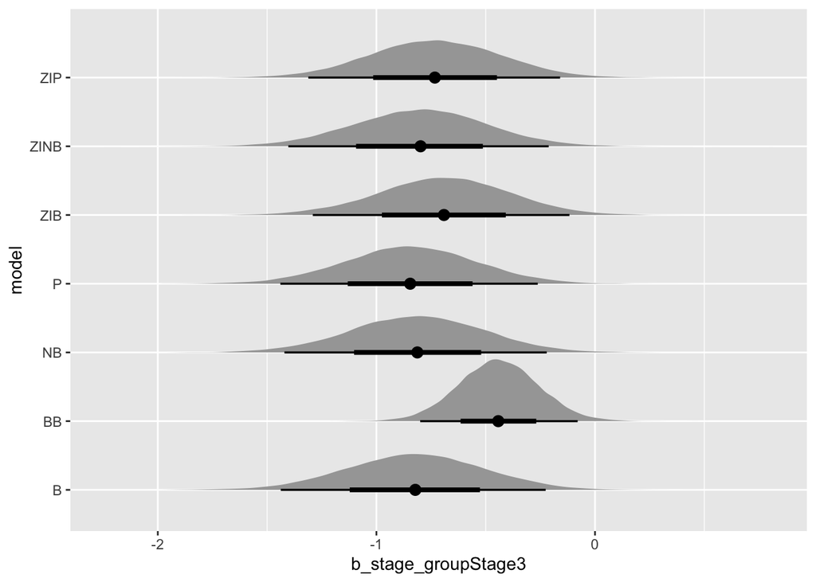

```r
posts %>%
  ggplot(aes(x = b_stage_groupStage3, y = model)) +
  stat_halfeye()
```

## 3.5 `cd15_opal_520_positive_cells`

The contents of the `BRMS_models_cd15_opal_520_positive_cells.RData` file are:

```r
rm(list = ls())
load("BRMS_models_cd15_opal_520_positive_cells.RData")
my_vars = as.data.frame(eapply(.GlobalEnv,typeof))
head(my_vars)
```

|  | time_fit2 | time_fit3 | time_fit4 | time_fit5 | time_fit6 | stan_beta_binomial2 | time_fit7 | beta_binomial2 | log_lik_beta_binomial2 | fit1 | fit2 | fit3 | fit4 | fit5 | fit6 | fit7 | stanvars | predict_beta_binomial2 | fitted_beta_binomial2 | time_fit1 |
| --- | --- | --- | --- | --- | --- | --- | --- | --- | --- | --- | --- | --- | --- | --- | --- | --- | --- | --- | --- | --- |
| 1 | double | double | double | double | double | character | double | list | closure | list | list | list | list | list | list | list | list | closure | closure | double |

```r
post1 = data.frame(b_stage_groupStage3 = posterior_samples(fit1)$b_stage_groupStage3, model = rep("B", 40000))
post2 = data.frame(b_stage_groupStage3 = posterior_samples(fit2)$b_stage_groupStage3, model = rep("P", 40000))
post3 = data.frame(b_stage_groupStage3 = posterior_samples(fit3)$b_stage_groupStage3, model = rep("NB", 40000))
post4 = data.frame(b_stage_groupStage3 = posterior_samples(fit4)$b_stage_groupStage3, model = rep("ZIB", 40000))
post5 = data.frame(b_stage_groupStage3 = posterior_samples(fit5)$b_stage_groupStage3, model = rep("ZIP", 40000))
post6 = data.frame(b_stage_groupStage3 = posterior_samples(fit6)$b_stage_groupStage3, model = rep("ZINB", 40000))
post7 = data.frame(b_stage_groupStage3 = posterior_samples(fit7)$b_stage_groupStage3, model = rep("BB", 40000))
posts = rbind(post1,post2,post3,post4,post5,post6,post7)
head(posts)
```

|  | b_stage_groupStage3 | model |
| --- | --- | --- |
| 1 | -0.7898445 | B |
| 2 | -0.9572583 | B |
| 3 | -0.8497122 | B |
| 4 | -0.9099758 | B |
| 5 | -1.0334300 | B |
| 6 | -1.1063844 | B |

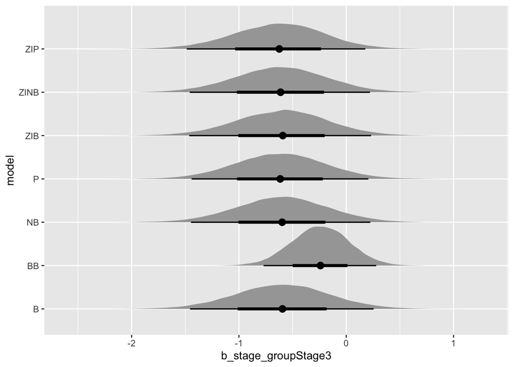

```r
posts %>%
  ggplot(aes(x = b_stage_groupStage3, y = model)) +
  stat_halfeye()
```

## 3.6 `cd3plus_foxp3plus_cells`

The contents of the `BRMS_models_cd3plus_foxp3plus_cells.RData` file are:

```r
rm(list = ls())
load("BRMS_models_cd3plus_foxp3plus_cells.RData")
my_vars = as.data.frame(eapply(.GlobalEnv,typeof))
head(my_vars)
```

|  | time_fit2 | time_fit3 | time_fit4 | time_fit5 | stan_beta_binomial2 | time_fit6 | time_fit7 | beta_binomial2 | log_lik_beta_binomial2 | fit1 | fit2 | fit3 | fit4 | fit5 | fit6 | fit7 | stanvars | predict_beta_binomial2 | fitted_beta_binomial2 | time_fit1 |
| --- | --- | --- | --- | --- | --- | --- | --- | --- | --- | --- | --- | --- | --- | --- | --- | --- | --- | --- | --- | --- |
| 1 | double | double | double | double | character | double | double | list | closure | list | list | list | list | list | list | list | list | closure | closure | double |

```r
post1 = data.frame(b_stage_groupStage3 = posterior_samples(fit1)$b_stage_groupStage3, model = rep("B", 40000))
post2 = data.frame(b_stage_groupStage3 = posterior_samples(fit2)$b_stage_groupStage3, model = rep("P", 40000))
post3 = data.frame(b_stage_groupStage3 = posterior_samples(fit3)$b_stage_groupStage3, model = rep("NB", 40000))
post4 = data.frame(b_stage_groupStage3 = posterior_samples(fit4)$b_stage_groupStage3, model = rep("ZIB", 40000))
post5 = data.frame(b_stage_groupStage3 = posterior_samples(fit5)$b_stage_groupStage3, model = rep("ZIP", 40000))
post6 = data.frame(b_stage_groupStage3 = posterior_samples(fit6)$b_stage_groupStage3, model = rep("ZINB", 40000))
post7 = data.frame(b_stage_groupStage3 = posterior_samples(fit7)$b_stage_groupStage3, model = rep("BB", 40000))
posts = rbind(post1,post2,post3,post4,post5,post6,post7)
head(posts)
```

|  | b_stage_groupStage3 | model |
| --- | --- | --- |
| 1 | -0.5479982 | B |
| 2 | -0.5711391 | B |
| 3 | -0.5760761 | B |
| 4 | -0.4750787 | B |
| 5 | -0.5517799 | B |
| 6 | -0.5392031 | B |

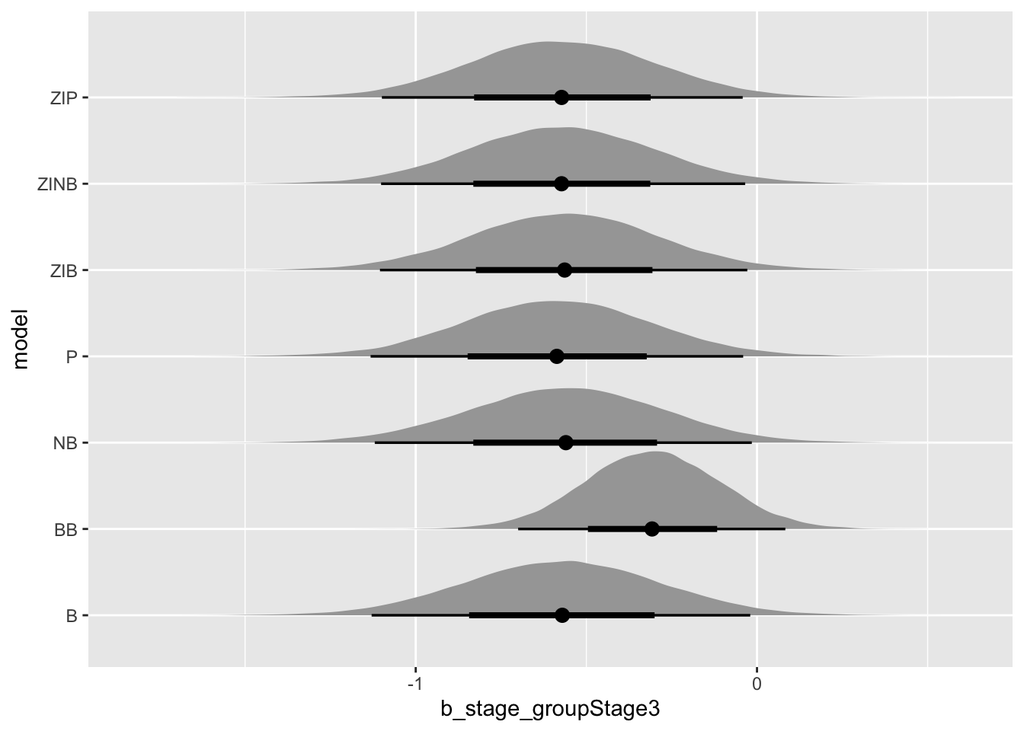

```r
posts %>%
  ggplot(aes(x = b_stage_groupStage3, y = model)) +
  stat_halfeye()
```

## 3.7 `cd3plus_cd8plus_cells`

The contents of the `BRMS_models_cd3plus_cd8plus_cells.RData` file are:

```r
rm(list = ls())
load("BRMS_models_cd3plus_cd8plus_cells.RData")
my_vars = as.data.frame(eapply(.GlobalEnv,typeof))
head(my_vars)
```

|  | predict_beta_binomial2 | fitted_beta_binomial2 | stanvars | beta_binomial2 | time_fit1 | time_fit2 | time_fit3 | time_fit4 | time_fit5 | time_fit6 | time_fit7 | stan_beta_binomial2 | fit1 | fit2 | fit3 | fit4 | fit5 | fit6 | fit7 | log_lik_beta_binomial2 |
| --- | --- | --- | --- | --- | --- | --- | --- | --- | --- | --- | --- | --- | --- | --- | --- | --- | --- | --- | --- | --- |
| 1 | closure | closure | list | list | double | double | double | double | double | double | double | character | list | list | list | list | list | list | list | closure |

```r
post1 = data.frame(b_stage_groupStage3 = posterior_samples(fit1)$b_stage_groupStage3, model = rep("B", 40000))
post2 = data.frame(b_stage_groupStage3 = posterior_samples(fit2)$b_stage_groupStage3, model = rep("P", 40000))
post3 = data.frame(b_stage_groupStage3 = posterior_samples(fit3)$b_stage_groupStage3, model = rep("NB", 40000))
post4 = data.frame(b_stage_groupStage3 = posterior_samples(fit4)$b_stage_groupStage3, model = rep("ZIB", 40000))
post5 = data.frame(b_stage_groupStage3 = posterior_samples(fit5)$b_stage_groupStage3, model = rep("ZIP", 40000))
post6 = data.frame(b_stage_groupStage3 = posterior_samples(fit6)$b_stage_groupStage3, model = rep("ZINB", 40000))
post7 = data.frame(b_stage_groupStage3 = posterior_samples(fit7)$b_stage_groupStage3, model = rep("BB", 40000))
posts = rbind(post1,post2,post3,post4,post5,post6,post7)
head(posts)
```

|  | b_stage_groupStage3 | model |
| --- | --- | --- |
| 1 | -0.7009010 | B |
| 2 | -0.7604728 | B |
| 3 | -0.7437357 | B |
| 4 | -0.6918767 | B |
| 5 | -0.5958270 | B |
| 6 | -0.5530601 | B |

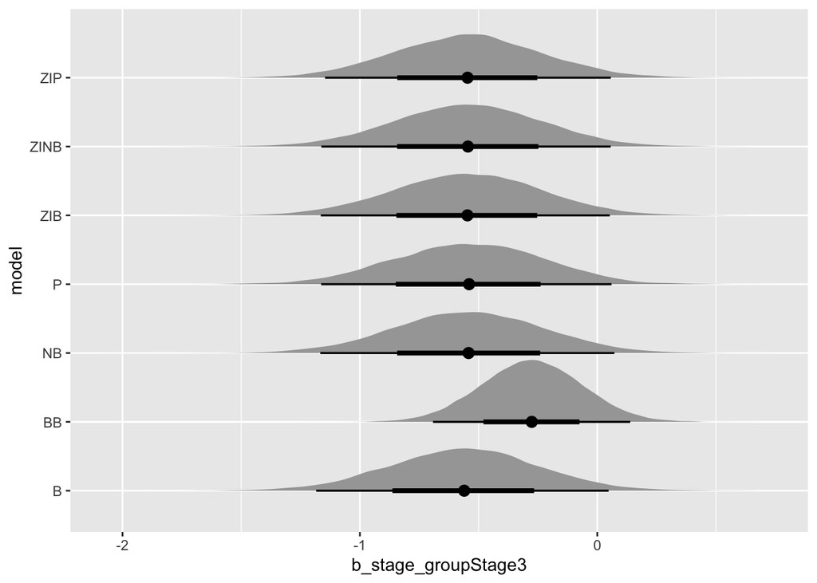

```r
posts %>%
  ggplot(aes(x = b_stage_groupStage3, y = model)) +
  stat_halfeye()
```

## 3.8 `cd11bplus_cd15plus_cells`

The contents of the `BRMS_models_cd11bplus_cd15plus_cells.RData` file are:

```r
rm(list = ls())
load("BRMS_models_cd11bplus_cd15plus_cells.RData")
my_vars = as.data.frame(eapply(.GlobalEnv,typeof))
head(my_vars)
```

|  | predict_beta_binomial2 | fitted_beta_binomial2 | stanvars | beta_binomial2 | time_fit1 | time_fit2 | time_fit3 | time_fit4 | time_fit5 | time_fit6 | time_fit7 | stan_beta_binomial2 | fit1 | fit2 | fit3 | fit4 | fit5 | fit6 | fit7 | log_lik_beta_binomial2 |
| --- | --- | --- | --- | --- | --- | --- | --- | --- | --- | --- | --- | --- | --- | --- | --- | --- | --- | --- | --- | --- |
| 1 | closure | closure | list | list | double | double | double | double | double | double | double | character | list | list | list | list | list | list | list | closure |

```r
post1 = data.frame(b_stage_groupStage3 = posterior_samples(fit1)$b_stage_groupStage3, model = rep("B", 40000))
post2 = data.frame(b_stage_groupStage3 = posterior_samples(fit2)$b_stage_groupStage3, model = rep("P", 40000))
post3 = data.frame(b_stage_groupStage3 = posterior_samples(fit3)$b_stage_groupStage3, model = rep("NB", 40000))
post4 = data.frame(b_stage_groupStage3 = posterior_samples(fit4)$b_stage_groupStage3, model = rep("ZIB", 40000))
post5 = data.frame(b_stage_groupStage3 = posterior_samples(fit5)$b_stage_groupStage3, model = rep("ZIP", 40000))
post6 = data.frame(b_stage_groupStage3 = posterior_samples(fit6)$b_stage_groupStage3, model = rep("ZINB", 40000))
post7 = data.frame(b_stage_groupStage3 = posterior_samples(fit7)$b_stage_groupStage3, model = rep("BB", 40000))
posts = rbind(post1,post2,post3,post4,post5,post6,post7)
head(posts)
```

|  | b_stage_groupStage3 | model |
| --- | --- | --- |
| 1 | 0.2871397 | B |
| 2 | 0.1520467 | B |
| 3 | 0.2218898 | B |
| 4 | -0.8297840 | B |
| 5 | -1.0246609 | B |
| 6 | -0.1912070 | B |

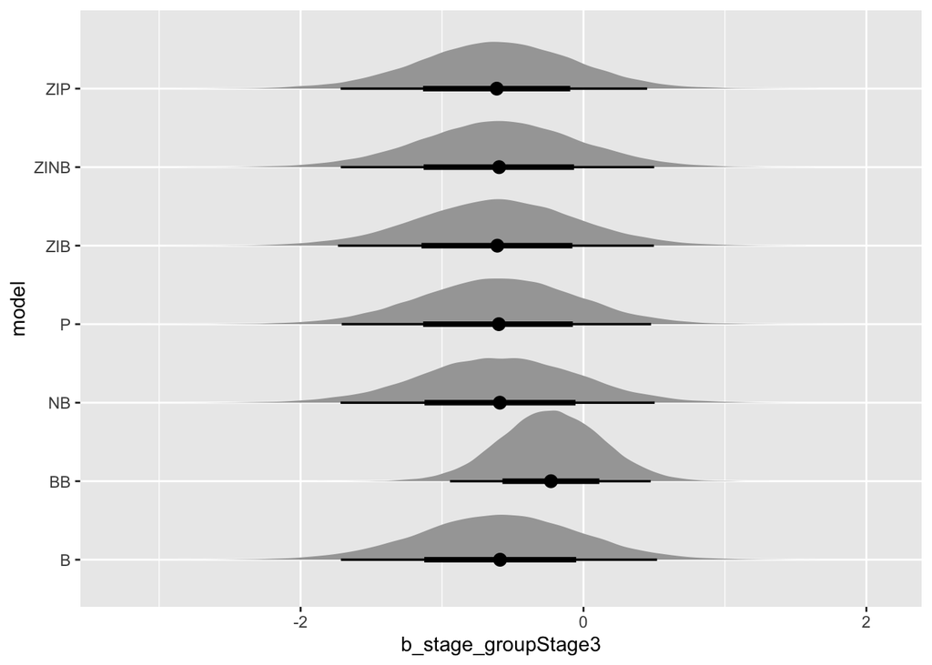

```r
posts %>%
  ggplot(aes(x = b_stage_groupStage3, y = model)) +
  stat_halfeye()
```